# MSDS7331_Team3_Lab2

## MSDS 7331: Data Mining

## Lab 2: Classification

## 7 July 2019

## Authors: Meredith Ludlow, Anand Rajan, Kristen Rollins, and Tej Tenmattam

# Data Preparation Part 1

**Rubric 1:** Define and prepare your class variables. Use proper variable representations (int, float, one-hot, etc.). Use pre-processing methods (as needed) for dimensionality reduction, scaling, etc. Remove variables that are not needed/useful for the analysis.

The two classification tasks for our 2017 census dataset are to predict whether a given census tract has a high or a low unemployment rate, as well as a high or low child poverty rate, based on other relevant factors. This is an important task, as it enables certain areas to be flagged as needing economic development or aid. Below, we first prepared our data for classification by cleaning it (in the same way as Lab 1), as well as removing unnecessary and redundant variables.

```python
# importing necessary packages
import pandas as pd
import numpy as np
import matplotlib.pyplot as plt
%matplotlib inline
import seaborn as sns

# Set seaborn plot styles
sns.set_style('darkgrid')
sns.set_color_codes('muted')

import warnings
warnings.filterwarnings("ignore") # ignore warnings for clean report

# df.head() displays all the columns without truncating
pd.set_option('display.max_columns', None)

# read csv file as pandas dataframe
df_17_census = pd.read_csv('../Data/acs2017_census_tract_data.csv')
```

```python
# Clean dataset as in lab 1
df_17_census.set_index('TractId', inplace=True) # set tract id as index

# Drop tracts where population is 0
df_17_cln = df_17_census.drop(df_17_census[df_17_census.TotalPop == 0].index)

# Drop tracts where child poverty or unemployment is null
df_17_cln = df_17_cln[np.isfinite(df_17_cln['ChildPoverty'])]
df_17_cln = df_17_cln[np.isfinite(df_17_cln['Unemployment'])]

# Impute to the median by each state
df_grouped = df_17_cln.groupby('State').transform(lambda x: x.fillna(x.median()))
df_17_cln['Income'] = df_grouped['Income']
df_17_cln['IncomeErr'] = df_grouped['IncomeErr']

# Impute remaining values to the overall median
df_17_cln = df_17_cln.fillna(df_17_cln.median())
```

```python
df_17_cln.describe()
```

|  | TotalPop | Men | Women | Hispanic | White | Black | Native | Asian | Pacific | VotingAgeCitizen | Income | IncomeErr | IncomePerCap | IncomePerCapErr | Poverty | ChildPoverty | Professional | Service | Office | Construction | Production | Drive | Carpool | Transit | Walk | OtherTransp | WorkAtHome | MeanCommute | Employed | … |
| --- | --- | --- | --- | --- | --- | --- | --- | --- | --- | --- | --- | --- | --- | --- | --- | --- | --- | --- | --- | --- | --- | --- | --- | --- | --- | --- | --- | --- | --- | --- |
| count | 72889.000000 | 72889.000000 | 72889.000000 | 72889.000000 | 72889.000000 | 72889.000000 | 72889.000000 | 72889.000000 | 72889.000000 | 72889.000000 | 72889.000000 | 72889.000000 | 72889.000000 | 72889.000000 | 72889.000000 | 72889.000000 | 72889.000000 | 72889.000000 | 72889.000000 | 72889.000000 | 72889.000000 | 72889.000000 | 72889.000000 | 72889.000000 | 72889.00000 | 72889.000000 | 72889.000000 | 72889.000000 | 72889.000000 | … |
| mean | 4438.372759 | 2182.350698 | 2256.022061 | 17.290081 | 61.312817 | 13.268165 | 0.729703 | 4.752853 | 0.146698 | 3137.878459 | 61111.961002 | 9694.920825 | 30702.626734 | 4259.381073 | 16.067164 | 21.155081 | 35.566003 | 18.855030 | 23.407072 | 9.256663 | 12.915429 | 75.823635 | 9.323555 | 5.387234 | 2.95396 | 1.888721 | 4.623234 | 26.078983 | 2078.009535 | … |
| std | 2192.532931 | 1101.516460 | 1126.275010 | 23.097490 | 30.635700 | 21.598962 | 4.525143 | 8.992743 | 1.023074 | 1514.686755 | 30492.084659 | 6135.953813 | 16059.781976 | 3019.532445 | 12.514595 | 18.643563 | 15.093914 | 8.037855 | 5.653534 | 5.979854 | 7.629365 | 15.062128 | 5.167761 | 11.659900 | 5.39858 | 2.518341 | 3.821944 | 7.101069 | 1121.667248 | … |
| min | 4.000000 | 0.000000 | 0.000000 | 0.000000 | 0.000000 | 0.000000 | 0.000000 | 0.000000 | 0.000000 | 1.000000 | 2692.000000 | 728.000000 | 949.000000 | 308.000000 | 0.000000 | 0.000000 | 0.000000 | 0.000000 | 0.000000 | 0.000000 | 0.000000 | 0.000000 | 0.000000 | 0.000000 | 0.00000 | 0.000000 | 0.000000 | 4.200000 | 0.000000 | … |
| 25% | 2953.000000 | 1438.000000 | 1491.000000 | 2.600000 | 38.100000 | 0.800000 | 0.000000 | 0.200000 | 0.000000 | 2093.000000 | 40400.000000 | 5740.000000 | 20603.000000 | 2507.000000 | 6.900000 | 6.200000 | 24.700000 | 13.300000 | 19.700000 | 5.000000 | 7.100000 | 72.300000 | 5.800000 | 0.000000 | 0.40000 | 0.400000 | 2.000000 | 21.100000 | 1302.000000 | … |
| 50% | 4133.000000 | 2022.000000 | 2100.000000 | 7.400000 | 70.400000 | 3.800000 | 0.000000 | 1.500000 | 0.000000 | 2924.000000 | 54434.000000 | 8273.000000 | 27242.000000 | 3405.000000 | 12.600000 | 16.300000 | 33.300000 | 17.700000 | 23.200000 | 8.400000 | 11.800000 | 79.900000 | 8.500000 | 1.000000 | 1.40000 | 1.200000 | 3.800000 | 25.400000 | 1913.000000 | … |
| 75% | 5530.000000 | 2717.000000 | 2815.000000 | 21.100000 | 87.700000 | 14.500000 | 0.400000 | 5.000000 | 0.000000 | 3920.000000 | 74673.000000 | 11899.000000 | 36429.000000 | 4965.000000 | 21.800000 | 31.600000 | 44.900000 | 23.300000 | 26.900000 | 12.500000 | 17.500000 | 84.900000 | 11.900000 | 4.600000 | 3.30000 | 2.500000 | 6.300000 | 30.300000 | 2649.000000 | … |
| max | 65528.000000 | 32266.000000 | 33262.000000 | 100.000000 | 100.000000 | 100.000000 | 100.000000 | 91.400000 | 71.900000 | 39389.000000 | 249750.000000 | 153365.000000 | 220253.000000 | 84414.000000 | 100.000000 | 100.000000 | 100.000000 | 100.000000 | 100.000000 | 100.000000 | 100.000000 | 100.000000 | 100.000000 | 100.000000 | 100.00000 | 100.000000 | 100.000000 | 73.900000 | 28945.000000 | … |

```python
# Categorize the unemployed percentages into binary categories
# Make cutoff using median of clean dataset, so groups are roughly equal
df_17_cln['HighUnemployment'] = pd.cut(df_17_cln.Unemployment,[-1,6,101],labels=[0,1])
df_17_cln.HighUnemployment = df_17_cln.HighUnemployment.astype(np.int)
# 0 indicates low unemployment rate, 1 indicates high unemployment rate

# Categorize the child poverty percentages into binary categories
# Make cutoff using median of clean dataset, so groups are roughly equal
df_17_cln['HighChildPoverty'] = pd.cut(df_17_cln.ChildPoverty,[-1,16.3,101],labels=[0,1])
df_17_cln.HighChildPoverty = df_17_cln.HighChildPoverty.astype(np.int)
# 0 indicates low child poverty rate, 1 indicates high child poverty rate

df_17_cln.info() # matches cleaned dataset from lab 1
```

```
<class 'pandas.core.frame.DataFrame'>
Int64Index: 72889 entries, 1001020100 to 72153750602
Data columns (total 38 columns):
State               72889 non-null object
County              72889 non-null object
TotalPop            72889 non-null int64
Men                 72889 non-null int64
Women               72889 non-null int64
Hispanic            72889 non-null float64
White               72889 non-null float64
Black               72889 non-null float64
Native              72889 non-null float64
Asian               72889 non-null float64
Pacific             72889 non-null float64
VotingAgeCitizen    72889 non-null int64
Income              72889 non-null float64
IncomeErr           72889 non-null float64
IncomePerCap        72889 non-null float64
IncomePerCapErr     72889 non-null float64
Poverty             72889 non-null float64
ChildPoverty        72889 non-null float64
Professional        72889 non-null float64
Service             72889 non-null float64
Office              72889 non-null float64
Construction        72889 non-null float64
Production          72889 non-null float64
Drive               72889 non-null float64
Carpool             72889 non-null float64
Transit             72889 non-null float64
Walk                72889 non-null float64
OtherTransp         72889 non-null float64
WorkAtHome          72889 non-null float64
MeanCommute         72889 non-null float64
Employed            72889 non-null int64
PrivateWork         72889 non-null float64
PublicWork          72889 non-null float64
SelfEmployed        72889 non-null float64
FamilyWork          72889 non-null float64
Unemployment        72889 non-null float64
HighUnemployment    72889 non-null int32
HighChildPoverty    72889 non-null int32
dtypes: float64(29), int32(2), int64(5), object(2)
memory usage: 21.1+ MB
```

At this point we have a clean dataset with no missing values, that matches the info from the cleaned dataset we used in Lab 1. Our target variables are "HighUnemployment" and "HighChildPoverty", which we encoded so that 1 signifies a tract with a high unemployment rate or high child poverty rate and a 0 indicates low unemployment or low child poverty respectively. We created the cutoff between high and low unemployment to be 6 percent, which was the median value for the unemployment attribute. Similarly, we used the median value of 16.3 as the cutoff for high and low child poverty rates. By using the median to separate the groups, the classes will be of roughly the same size.

Since this dataset has 38 variables, next we eliminate some unnecessary and redundant variables to cut down on the high dimensionality of the dataset. Here we eliminate variables based on the pairwise correlation plot we created in Lab 1 and intuition. In the Mini Lab, we further reduced the dataset down to only 6 important features based on PCA, but the models using that dataset were not as accurate. Thus we will use this "full" dataset of 28 variables (with 26 predictors) throughout this lab.

Here we also perform scaling, so that the previously integer attributes are now percentages. In this way most of the predictors are percentages of the total population.

```python
# Create dataframe to use in logistic and SVM models
df_17_model = df_17_cln.copy()

# Eliminate non-useful and redundant variables
del df_17_model['State'] # encoding would result in too many added variables
del df_17_model['County'] # encoding would result in too many added variables
del df_17_model['Men'] # redundant to keep men and women
del df_17_model['Unemployment'] # already encoded to binary
del df_17_model['ChildPoverty'] # already encoded to binary

# Eliminate more variables based on correlation plot (could maybe remove more)
del df_17_model['IncomeErr'] # only need to keep one income-related variable
del df_17_model['IncomePerCap'] # only need to keep one income-related variable
del df_17_model['IncomePerCapErr'] # only need to keep one income-related variable
del df_17_model['Transit'] # drive and transit were essentially inverses
del df_17_model['PublicWork'] # private and public work were essentially inverses

# All remaining variables are ints or floats so we do not have to do one-hot encoding

# Convert columns to percentages for consistency
df_17_model['Women'] = round(df_17_model['Women']/df_17_model['TotalPop']*100,1)
df_17_model['VotingAgeCitizen'] = round(df_17_model['VotingAgeCitizen']/df_17_model['TotalPop']*100,1)
df_17_model['Employed'] = round(df_17_model['Employed']/df_17_model['TotalPop']*100,1)

print(df_17_model.info())
df_17_model.head()
```

```
<class 'pandas.core.frame.DataFrame'>
Int64Index: 72889 entries, 1001020100 to 72153750602
Data columns (total 28 columns):
TotalPop            72889 non-null int64
Women               72889 non-null float64
Hispanic            72889 non-null float64
White               72889 non-null float64
Black               72889 non-null float64
Native              72889 non-null float64
Asian               72889 non-null float64
Pacific             72889 non-null float64
VotingAgeCitizen    72889 non-null float64
Income              72889 non-null float64
Poverty             72889 non-null float64
Professional        72889 non-null float64
Service             72889 non-null float64
Office              72889 non-null float64
Construction        72889 non-null float64
Production          72889 non-null float64
Drive               72889 non-null float64
Carpool             72889 non-null float64
Walk                72889 non-null float64
OtherTransp         72889 non-null float64
WorkAtHome          72889 non-null float64
MeanCommute         72889 non-null float64
Employed            72889 non-null float64
PrivateWork         72889 non-null float64
SelfEmployed        72889 non-null float64
FamilyWork          72889 non-null float64
HighUnemployment    72889 non-null int32
HighChildPoverty    72889 non-null int32
dtypes: float64(25), int32(2), int64(1)
memory usage: 15.6 MB
None
```

| TractId | TotalPop | Women | Hispanic | White | Black | Native | Asian | Pacific | VotingAgeCitizen | Income | Poverty | Professional | Service | Office | Construction | Production | Drive | Carpool | Walk | OtherTransp | WorkAtHome | MeanCommute | Employed | PrivateWork | SelfEmployed | FamilyWork | HighUnemployment | HighChildPoverty |
| --- | --- | --- | --- | --- | --- | --- | --- | --- | --- | --- | --- | --- | --- | --- | --- | --- | --- | --- | --- | --- | --- | --- | --- | --- | --- | --- | --- | --- |
| 1001020100 | 1845 | 51.3 | 2.4 | 86.3 | 5.2 | 0.0 | 1.2 | 0.0 | 76.3 | 67826.0 | 10.7 | 38.5 | 15.6 | 22.8 | 10.8 | 12.4 | 94.2 | 3.3 | 0.5 | 0.0 | 2.1 | 24.5 | 47.8 | 74.2 | 4.5 | 0.0 | 0 | 1 |
| 1001020200 | 2172 | 46.3 | 1.1 | 41.6 | 54.5 | 0.0 | 1.0 | 0.0 | 76.1 | 41287.0 | 22.4 | 30.5 | 24.9 | 22.9 | 6.3 | 15.4 | 90.5 | 9.1 | 0.0 | 0.5 | 0.0 | 22.2 | 39.2 | 75.9 | 9.0 | 0.0 | 0 | 1 |
| 1001020300 | 3385 | 54.7 | 8.0 | 61.4 | 26.5 | 0.6 | 0.7 | 0.4 | 73.3 | 46806.0 | 14.7 | 27.9 | 19.4 | 33.3 | 9.9 | 9.6 | 88.3 | 8.4 | 1.0 | 0.8 | 1.5 | 23.1 | 43.8 | 73.3 | 4.8 | 0.7 | 0 | 1 |
| 1001020400 | 4267 | 53.1 | 9.6 | 80.3 | 7.1 | 0.5 | 0.2 | 0.0 | 76.3 | 55895.0 | 2.3 | 29.0 | 16.6 | 25.8 | 9.1 | 19.5 | 82.3 | 11.2 | 1.5 | 2.9 | 2.1 | 25.9 | 43.3 | 75.8 | 4.5 | 0.0 | 1 | 0 |
| 1001020500 | 9965 | 49.3 | 0.9 | 77.5 | 16.4 | 0.0 | 3.1 | 0.0 | 72.5 | 68143.0 | 12.2 | 48.8 | 13.8 | 20.5 | 3.5 | 13.4 | 86.9 | 11.2 | 0.8 | 0.3 | 0.7 | 21.0 | 48.0 | 71.4 | 4.5 | 0.0 | 0 | 1 |

```python
# create X and y variables to use in models
# y_u is for unemployment, y_cp is for child poverty
if 'HighUnemployment' in df_17_model:
    y_u = df_17_model['HighUnemployment'].values # get the labels we want
    del df_17_model['HighUnemployment'] # get rid of the class label
if 'HighChildPoverty' in df_17_model:
    y_cp = df_17_model['HighChildPoverty'].values # get the labels we want
    del df_17_model['HighChildPoverty'] # get rid of the class label
X = df_17_model.values # use everything else to predict
```

# Data Preparation Part 2

**Rubric 2:** Describe the final dataset that is used for classification/regression (include a description of any newly formed variables you created).

Our final dataset used for classification is very similar to the full dataset provided by the U.S. Census Bureau. The differences are that a few variables have been removed due to redundancy, three variables have been converted to percentages rather than counts (Women, VotingAgeCitizen, and Employed), and our target class variables of Unemployment and ChildPoverty have been converted to binary indicator variables.

| Attribute | Data Type | Description |
| --- | --- | --- |
| TotalPop | Integer | Total population of the census area |
| Women | Decimal | Percentage of total population that are women |
| Hispanic | Decimal | Percentage of population that is Hispanic/Latino |
| White | Decimal | Percentage of population that is white |
| Black | Decimal | Percentage of population that is black |
| Native | Decimal | Percent of population that is Native American |
| Asian | Decimal | Percent of population that is Asian |
| Pacific | Decimal | Percent of population that is Native Hawaiian or other Pacific Islander |
| VotingAgeCitizen | Decimal | Percentage of population that are voting age citizens |
| Income | Decimal | Median household income in USD ($) |
| Poverty | Decimal | Percentage of population under the poverty level |
| Professional | Decimal | Percent employed in management, business, science, and arts |
| Service | Decimal | Percent employed in service jobs |
| Office | Decimal | Percent employed in sales and office jobs |
| Construction | Decimal | Percent employed in natural resources, construction, and maintenance |
| Production | Decimal | Percent employed in production, transportation, and material movement |
| Drive | Decimal | Percent commuting alone in a car, van, or truck |
| Carpool | Decimal | Percent carpooling in a car, van, or truck |
| Walk | Decimal | Percent walking to work |
| OtherTransp | Decimal | Percent commuting via other means |
| WorkAtHome | Decimal | Percentage working at home |
| MeanCommute | Decimal | Mean commute time in minutes |
| Employed | Decimal | Percentage of people employed (16+) |
| PrivateWork | Decimal | Percentage employed in private industry |
| SelfEmployed | Decimal | Percentage self-employed |
| FamilyWork | Decimal | Percentage in unpaid family work |
| HighUnemployment | Binary | Indication of a high rate of unemployment for the census tract |
| HighChildPoverty | Binary | Indication of a high rate of children living under the poverty level |

# Modeling and Evaluation 1

**Rubric 3:** Choose and explain your evaluation metrics that you will use (i.e., accuracy, precision, recall, F-measure, or any metric we have discussed). Why are the measure(s) appropriate for analyzing the results of your modeling? Give a detailed explanation backing up any assertions.

The primary evaluation metric we will use for our classification tasks is accuracy, but we will examine precision and recall as well. Accuracy itself is appropriate for any classification task, as it measures what percentage of the observations were classified correctly. Precision and recall, however, are most appropriate for binary classification problems, which we are performing here. We can use the confusion matrix below to define formulas for precision and recall:

| * | Predicted: High | Predicted: Low |
| --- | --- | --- |
| **Actual: High** | TP | FN |
| **Actual: Low** | FP | TN |

From this we have $Precision = \frac{TP}{TP+FP}$ and $Recall = \frac{TP}{TP+FN}$. This means that high precision corresponds to low false positives, and high recall means low false negatives.

Accuracy is already a good metric for our dataset, because there is no class imbalance. We have defined our target class variables to be split such that half of the observations are considered to have high unemployment and half have low unemployment, and we made a similar split for child poverty. Problems often arise using accuracy when there is large class imbalance, but if a classifier tried to predict the same class for all observations in our dataset, it would only attain 50% accuracy. Thus if we see accuracies much higher than 50%, this is a good indication that the models are performing well.

Precision and recall are also helpful to us based on the people who might be using these models. If a model attains high precision, i.e. there are few false positives, this means that the model did not flag many census tracts that actually had low unemployment or child poverty as ones needing aid. High precision would be good for an organization that has limited resources, i.e. they can only help so many neighborhoods, so they want to make sure the ones they target are actually in need of economic development or aid.

On the other hand, if a model has high recall, i.e. there are few false negatives, this means that when census tracts have high unemployment or child poverty the model correctly identifies them. This would be appropriate for an organization that has extensive resources that wants to aid in all areas that need it, or at least identify/flag all of those areas for future development.

Therefore we will look at accuracy, precision and recall for our classification tasks.

# Modeling and Evaluation 2

**Rubric 4:** Choose the method you will use for dividing your data into training and testing splits (i.e., are you using Stratified 10-fold cross validation? Why?). Explain why your chosen method is appropriate or use more than one method as appropriate. For example, if you are using time series data then you should be using continuous training and testing sets across time.

The method we used to divide our data into training and testing sets is a stratified shuffle split. Unlike the k-fold stratified split, it splits once but shuffles the data before the split. Here sklearn allows us to pick the number of splits. The cv object is a combination of stratified k-fold and stratified randomized folds and the folds are preserved per the samples on each classification. However in the stratified shuffle split the data overlap in folds.

Stratification is appropriate for our dataset as a precautionary measure. Our target class variables are already split close to 50/50, but using stratification ensures that this ratio is maintained and not skewed by random chance. In addition, we used a 80/20 train/test split because we have a fairly large amount of data (70k+ observations). For large datasets, is it appropriate to use a smaller percentage for the test set because there is still plenty to test on, whereas a smaller dataset might necessitate a 60/40 or even a 50/50 train/test split.

```python
from sklearn.neighbors import KNeighborsClassifier
from sklearn.metrics import accuracy_score, precision_score, recall_score
from IPython.html import widgets
from sklearn.model_selection import StratifiedShuffleSplit
from time import time

cv_u = StratifiedShuffleSplit(n_splits = 1, test_size = 0.2, train_size=0.8)
cv_u.get_n_splits(X,y_u)

for trainidx, testidx in cv_u.split(X,y_u):
    X_trainU = X[trainidx]
    X_testU = X[testidx]
    y_trainU = y_u[trainidx]
    y_testU = y_u[testidx]

cv_cp = StratifiedShuffleSplit(n_splits = 1, test_size = 0.2, train_size=0.8)
cv_cp.get_n_splits(X,y_cp)

for trainidx, testidx in cv_cp.split(X,y_cp):
    X_trainCP = X[trainidx]
    X_testCP = X[testidx]
    y_trainCP = y_cp[trainidx]
    y_testCP = y_cp[testidx]
```

# Modeling and Evaluation 3

**Rubric 5:** Create three different classification/regression models for each task (e.g., random forest, KNN, and SVM for task one and the same or different algorithms for task two). Two modeling techniques must be new (but the third could be SVM or logistic regression). Adjust parameters as appropriate to increase generalization performance using your chosen metric. You must investigate different parameters of the algorithms!

Our two classification tasks are to predict unemployment and child poverty of census tracts based on other attributes of the neighborhood. For both of these tasks, we have created KNN, Naive Bayes, and Random Forest models.

### KNN algorithm

This is one of the simplest among supervised machine learning algorithms. It calculates the distance of all the new data points to the training data points. It could be Euclidean distance or Manhattan, and selectes the K nearest points to the original one where K is an integer. Finally, it assigns the datapoint to the class for which the data point becomes the majority one.

#### KNN model for predicting Unemployment

```python
for K in range(1,20):
    clf = KNeighborsClassifier(n_neighbors=K, weights='uniform', metric='euclidean')
    clf.fit(X_trainU,y_trainU)
    y_hatU = clf.predict(X_testU)
    accuracy = accuracy_score(y_testU,y_hatU)
    precision = precision_score(y_testU, y_hatU)
    recall = recall_score(y_testU, y_hatU)
    print('Classifier with %d neighbors: Accuracy %.2f, Precision %.2f, Recall %.2f'%(K,accuracy,precision,recall))
```

```
Classifier with 1 neighbors: Accuracy 0.62, Precision 0.61, Recall 0.60
Classifier with 2 neighbors: Accuracy 0.62, Precision 0.70, Recall 0.41
Classifier with 3 neighbors: Accuracy 0.64, Precision 0.64, Recall 0.61
Classifier with 4 neighbors: Accuracy 0.65, Precision 0.70, Recall 0.49
Classifier with 5 neighbors: Accuracy 0.65, Precision 0.66, Recall 0.61
Classifier with 6 neighbors: Accuracy 0.66, Precision 0.70, Recall 0.53
Classifier with 7 neighbors: Accuracy 0.67, Precision 0.67, Recall 0.63
Classifier with 8 neighbors: Accuracy 0.67, Precision 0.71, Recall 0.56
Classifier with 9 neighbors: Accuracy 0.67, Precision 0.67, Recall 0.63
Classifier with 10 neighbors: Accuracy 0.67, Precision 0.71, Recall 0.57
Classifier with 11 neighbors: Accuracy 0.67, Precision 0.68, Recall 0.63
Classifier with 12 neighbors: Accuracy 0.67, Precision 0.70, Recall 0.58
Classifier with 13 neighbors: Accuracy 0.67, Precision 0.68, Recall 0.63
Classifier with 14 neighbors: Accuracy 0.68, Precision 0.71, Recall 0.58
Classifier with 15 neighbors: Accuracy 0.68, Precision 0.69, Recall 0.63
Classifier with 16 neighbors: Accuracy 0.68, Precision 0.71, Recall 0.59
Classifier with 17 neighbors: Accuracy 0.68, Precision 0.69, Recall 0.63
Classifier with 18 neighbors: Accuracy 0.68, Precision 0.71, Recall 0.59
Classifier with 19 neighbors: Accuracy 0.68, Precision 0.69, Recall 0.63
```

It appears that K=19 is the best parameter for this task, as it produces the highest accuracy, is an odd number (best practice for a two-class problem, so no ties occur), and produces the best precision and recall among the models with K=15, K=17 and K=19.

```python
bestK_u = 19
```

#### KNN for predicting Child Poverty

```python
for K in range(1,25):
    clf = KNeighborsClassifier(n_neighbors=K, weights='uniform', metric='euclidean')
    clf.fit(X_trainCP,y_trainCP)
    y_hatCP = clf.predict(X_testCP)
    accuracy = accuracy_score(y_testCP,y_hatCP)
    precision = precision_score(y_testCP, y_hatCP)
    recall = recall_score(y_testCP, y_hatCP)
    print('Classifier with %d neighbors: Accuracy %.2f, Precision %.2f, Recall %.2f'%(K,accuracy,precision,recall))
```

```
Classifier with 1 neighbors: Accuracy 0.73, Precision 0.73, Recall 0.72
Classifier with 2 neighbors: Accuracy 0.73, Precision 0.82, Recall 0.59
Classifier with 3 neighbors: Accuracy 0.76, Precision 0.77, Recall 0.75
Classifier with 4 neighbors: Accuracy 0.77, Precision 0.82, Recall 0.68
Classifier with 5 neighbors: Accuracy 0.77, Precision 0.78, Recall 0.76
Classifier with 6 neighbors: Accuracy 0.78, Precision 0.82, Recall 0.71
Classifier with 7 neighbors: Accuracy 0.78, Precision 0.79, Recall 0.77
Classifier with 8 neighbors: Accuracy 0.78, Precision 0.81, Recall 0.73
Classifier with 9 neighbors: Accuracy 0.78, Precision 0.79, Recall 0.77
Classifier with 10 neighbors: Accuracy 0.79, Precision 0.81, Recall 0.74
Classifier with 11 neighbors: Accuracy 0.79, Precision 0.79, Recall 0.78
Classifier with 12 neighbors: Accuracy 0.79, Precision 0.81, Recall 0.75
Classifier with 13 neighbors: Accuracy 0.79, Precision 0.79, Recall 0.78
Classifier with 14 neighbors: Accuracy 0.79, Precision 0.81, Recall 0.76
Classifier with 15 neighbors: Accuracy 0.79, Precision 0.79, Recall 0.78
Classifier with 16 neighbors: Accuracy 0.79, Precision 0.81, Recall 0.76
Classifier with 17 neighbors: Accuracy 0.79, Precision 0.79, Recall 0.78
Classifier with 18 neighbors: Accuracy 0.79, Precision 0.81, Recall 0.76
Classifier with 19 neighbors: Accuracy 0.79, Precision 0.80, Recall 0.78
Classifier with 20 neighbors: Accuracy 0.79, Precision 0.81, Recall 0.77
Classifier with 21 neighbors: Accuracy 0.79, Precision 0.80, Recall 0.78
Classifier with 22 neighbors: Accuracy 0.79, Precision 0.81, Recall 0.77
Classifier with 23 neighbors: Accuracy 0.79, Precision 0.80, Recall 0.78
Classifier with 24 neighbors: Accuracy 0.79, Precision 0.81, Recall 0.77
```

It appears that K=19 is the best parameter for this task, as it produces the highest accuracy and is an odd number (best practice for a two-class problem, so no ties occur). The models with K=21 and K=23 produce the same accuracy, precision, and recall, but the smaller value of K is preferred.

```python
bestK_cp = 19
```

### Naive Bayes Algorithm

Naive Bayes is the simplest of classification algorithms. It is fast and easy to implement quickly. It applies Bayes theorem of probability to predict the class of the data set. There are 3 types of Naive Bayes models:

a. Gaussian - Used to classify assuming the features are normally distributed

b. Multinomial - Used on discrete data (example: counts of a word in a document)

c. Bernoulli - Used if feature vectors are binary.

Here in our data set we have Unemployment and Child poverty both in binary and hence we used Bernoulli and Multinomial Naive Bayes.

#### Naive Bayes for predicting Unemployment

```python
from sklearn.naive_bayes import BernoulliNB
from sklearn.naive_bayes import MultinomialNB
from time import time
from sklearn.metrics import confusion_matrix

#Bernoulli Model:
clf_bnb = BernoulliNB(alpha=0.001, binarize=10)
clf_bnb.fit(X_trainU,y_trainU)
start = time()
y_hatU = clf_bnb.predict(X_testU)
end = time()
accuracy = round(accuracy_score(y_testU, y_hatU), 3)
precision = round(precision_score(y_testU, y_hatU), 3)
recall = round(recall_score(y_testU, y_hatU), 3)
nb_un_preds_bernoulli=y_hatU

#ROC and AUC
# predict probabilities
nb_un_bern_probs = clf_bnb.predict_proba(X_testU)
# keep probabilities for the positive outcome only
nb_un_bern_probs = nb_un_bern_probs[:, 1]

# Print the metrics
print('Accuracy for Bernoulli Model:', accuracy)
print('Precision for Bernoulli Model:', precision)
print('Recall for Bernoulli Model:', recall)
print('Latency in ms for Bernoulli Model:', round((end - start)*1000, 1))
print ("Confusion matrix for Bernoulli Model::", confusion_matrix(y_testU, y_hatU))
print('**************************************')

#Multinomial Model:
clf_mnb = MultinomialNB(alpha=0.001)
clf_mnb.fit(X_trainU,y_trainU)
start = time()
y_hatU = clf_mnb.predict(X_testU)
end = time()
accuracy = round(accuracy_score(y_testU,y_hatU), 3)
precision = round(precision_score(y_testU, y_hatU), 3)
recall = round(recall_score(y_testU, y_hatU), 3)
nb_un_preds_multinomial=y_hatU

#ROC and AUC
# predict probabilities
nb_un_multi_probs = clf_mnb.predict_proba(X_testU)
# keep probabilities for the positive outcome only
nb_un_multi_probs = nb_un_multi_probs[:, 1]

# Print the metrics
print('Accuracy for Multinomial Model:', accuracy)
print('Precision for Multinomial Model:', precision)
print('Recall for Multinomial Model:', recall)
print('Latency in ms for Multinomial Model:', round((end - start)*1000, 1))
print ("Confusion matrix for Multinomial Model::", confusion_matrix(y_testU, y_hatU))
```

```
Accuracy for Bernoulli Model: 0.702
Precision for Bernoulli Model: 0.687
Recall for Bernoulli Model: 0.728
Latency in ms for Bernoulli Model: 10.0
Confusion matrix for Bernoulli Model:: [[5011 2386]
 [1956 5225]]
Accuracy for Multinomial Model: 0.647
Precision for Multinomial Model: 0.635
Recall for Multinomial Model: 0.669
Latency in ms for Multinomial Model: 2.0
Confusion matrix for Multinomial Model:: [[4633 2764]
 [2378 4803]]
```

#### Naive Bayes for predicting Child Poverty

```python
#Bernoulli Model:
clf_bnb = BernoulliNB(alpha=0.001, binarize=10)
clf_bnb.fit(X_trainCP,y_trainCP)
start = time()
y_hatCP = clf_bnb.predict(X_testCP)
end = time()
accuracy = round(accuracy_score(y_testCP,y_hatCP), 3)
precision = round(precision_score(y_testCP,y_hatCP), 3)
recall = round(recall_score(y_testCP,y_hatCP), 3)
nb_cp_preds_bernoulli=y_hatCP

#ROC and AUC
# predict probabilities
nb_cp_bern_probs = clf_bnb.predict_proba(X_testCP)
# keep probabilities for the positive outcome only
nb_cp_bern_probs = nb_cp_bern_probs[:, 1]

# Print the metrics
print('Accuracy for Bernoulli Model:', accuracy)
print('Precision for Bernoulli Model:', precision)
print('Recall for Bernoulli Model:', recall)
print('Latency in ms for Bernoulli Model:', round((end - start)*1000, 1))
print ("Confusion matrix for Bernoulli Model::", confusion_matrix(y_testCP, y_hatCP))
print('**************************************')

#Multinomial Model:
clf_mnb = MultinomialNB(alpha=0.001)
clf_mnb.fit(X_trainCP,y_trainCP)
start = time()
y_hatCP = clf_mnb.predict(X_testCP)
end = time()
accuracy = round(accuracy_score(y_testCP,y_hatCP), 3)
precision = round(precision_score(y_testCP,y_hatCP), 3)
recall = round(recall_score(y_testCP,y_hatCP), 3)
nb_cp_preds_multinomial=y_hatCP

#ROC and AUC
# predict probabilities
nb_cp_multi_probs = clf_mnb.predict_proba(X_testCP)
# keep probabilities for the positive outcome only
nb_cp_multi_probs = nb_cp_multi_probs[:, 1]


# Print the metrics
print('Accuracy for Multinomial Model:', accuracy)
print('Precision for Multinomial Model:', precision)
print('Recall for Multinomial Model:', recall)
print('Latency in ms for Multinomial Model:', round((end - start)*1000, 1))
print ("Confusion matrix for Multinomial Model::", confusion_matrix(y_testCP, y_hatCP))
```

```
Accuracy for Bernoulli Model: 0.858
Precision for Bernoulli Model: 0.825
Recall for Bernoulli Model: 0.908
Latency in ms for Bernoulli Model: 9.5
Confusion matrix for Bernoulli Model:: [[5907 1397]
 [ 671 6603]]
Accuracy for Multinomial Model: 0.713
Precision for Multinomial Model: 0.712
Recall for Multinomial Model: 0.714
Latency in ms for Multinomial Model: 1.0
Confusion matrix for Multinomial Model:: [[5204 2100]
 [2082 5192]]
```

### Random Forest

Random forest works on constructing classification trees and grows from an input vector it receives down each of the trees in the forest. We term this as a 'vote' for a class. The forest ultimately chooses the tree classification that has the most among all the trees in the forest.

If we have several input variables and some of the input variables are selected at random it determines the best split among these variables, which is chosen for the node split. However, no pruning of the tree is done and each tree grows to its maximum. The Error rate depends on the correlation between two trees and the strenth of the tree. It is deemed that a tree with the lowest error rate is the strongest. We have to find the out of bag error rate. This is done when the training set for the current tree is drawn by sampling with replacement. We need to choose one-third of the cases will be left out of the sample. Thus, the out-of-bag data we get will be used for the estimate of the classification error when trees are added to the forest. Overfitting is not usual with Random Forest.

#### Random Forest for predicting Unemployment

```python
#Import the RF library from sklearn
from sklearn.ensemble import RandomForestClassifier
from sklearn.datasets import make_classification
from sklearn.metrics import roc_curve
from sklearn.metrics import accuracy_score
from sklearn.metrics import confusion_matrix
from time import time

# Supervised transformation based on random forests
rfclf = RandomForestClassifier(max_depth=5, n_estimators=10)
#Fitting RF model on training data
rfclf.fit(X_trainU, y_trainU)
rfclf_u = rfclf

# The random forest model prediction
start = time()
y_pred_rf = rfclf.predict_proba(X_testU)[0:10]
preds = rfclf.predict(X_testU)
end = time()
accuracy = round(accuracy_score(y_testU,preds), 3)
precision = round(precision_score(y_testU,preds), 3)
recall = round(recall_score(y_testU,preds), 3)
rf_preds_un=preds

#ROC and AUC
# predict probabilities
rf_un_probs = rfclf.predict_proba(X_testU)
# keep probabilities for the positive outcome only
rf_un_probs = rf_un_probs[:, 1]

# Print the metrics
print ("Accuracy for Random Forest Model: ", accuracy)
print('Precision for Random Forest Model:', precision)
print('Recall for Random Forest Model:', recall)
print('Latency in ms for Random Forest Model:', round((end - start)*1000, 1))
print (" Confusion matrix:", confusion_matrix(y_testU, preds))
```

```
Accuracy for Random Forest Model:  0.74
Precision for Random Forest Model: 0.756
Recall for Random Forest Model: 0.695
Latency in ms for Random Forest Model: 36.9
 Confusion matrix: [[5788 1609]
 [2188 4993]]
```

#### Random Forest for predicting Child Poverty

```python
#Import the RF library from sklearn
from sklearn.ensemble import RandomForestClassifier
from sklearn.datasets import make_classification
from sklearn.metrics import roc_curve
from sklearn.metrics import accuracy_score
from sklearn.metrics import confusion_matrix
from time import time

# Supervised transformation based on random forests
rfclf = RandomForestClassifier(max_depth=5, n_estimators=10)
#Fitting RF model on training data
rfclf.fit(X_trainCP, y_trainCP)
rfclf_cp = rfclf

# The random forest model prediction
start = time()
y_pred_rf = rfclf.predict_proba(X_testCP)[0:10]
preds = rfclf.predict(X_testCP)
end = time()
accuracy = round(accuracy_score(y_testCP,preds), 3)
precision = round(precision_score(y_testCP,preds), 3)
recall = round(recall_score(y_testCP,preds), 3)
cm_cp = confusion_matrix(y_testCP, preds)
rf_preds_cp=preds

#ROC and AUC
# predict probabilities
rf_cp_probs = rfclf.predict_proba(X_testCP)
# keep probabilities for the positive outcome only
rf_cp_probs = rf_cp_probs[:, 1]

# Print the metrics
print ("Accuracy for Random Forest Model: ", accuracy)
print('Precision for Random Forest Model:', precision)
print('Recall for Random Forest Model:', recall)
print('Latency in ms for Random Forest Model:', round((end - start)*1000, 1))
print ("Confusion matrix for Random Forest Model:", cm_cp)
```

```
Accuracy for Random Forest Model:  0.889
Precision for Random Forest Model: 0.885
Recall for Random Forest Model: 0.894
Latency in ms for Random Forest Model: 35.9
Confusion matrix for Random Forest Model: [[6460  844]
 [ 768 6506]]
```

# Modeling and Evaluation 4

**Rubric 6:** Analyze the results using your chosen method of evaluation. Use visualizations of the results to bolster the analysis. Explain any visuals and analyze why they are interesting to someone that might use this model.

For each of our predictive models, we created confusion matrices and ROC curves to visualize and analyze the performance of these models.

### Confusion Matrices

A Confusion Matrix is a 2x2 matrix with the following cells:

- **True Positive: (TP)**
  - Interpretation: Predicted positive and it's true.
- **True Negative: (TN)**
  - Interpretation: Predicted negative and it's true.
- **False Positive: (FP) - (Type 1 Error)**
  - Interpretation: Predicted positive and it's false.
- **False Negative: (FN) - (Type 2 Error)**
  - Interpretation: Predicted negative and it's false.

We describe predicted values as Positive and Negative and actual values as True and False. Out of combinations of these values, we can derive a set of different quality measures.

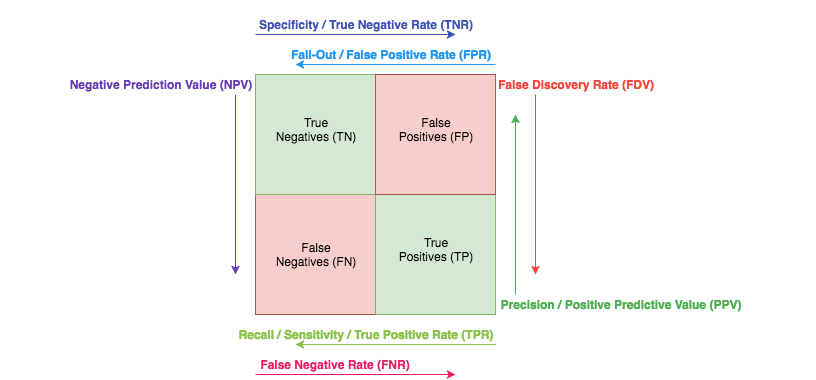

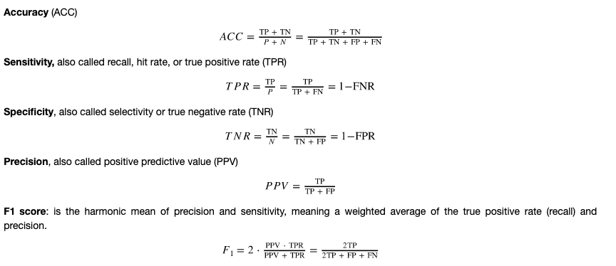

```python
# Function to plot confusion matrices
def cm_analysis(y_true, y_pred, labels, ymap=None, figsize=(8,8)):
    """
    Generate matrix plot of confusion matrix with pretty annotations.
    args:
      y_true:    true label of the data, with shape (nsamples,)
      y_pred:    prediction of the data, with shape (nsamples,)
      filename:  filename of figure file to save
      labels:    string array, name the order of class labels in the confusion matrix.
                 use `clf.classes_` if using scikit-learn models.
                 with shape (nclass,).
      ymap:      dict: any -> string, length == nclass.
                 if not None, map the labels & ys to more understandable strings.
                 Caution: original y_true, y_pred and labels must align.
      figsize:   the size of the figure plotted.
    """
    if ymap is not None:
        y_pred = [ymap[yi] for yi in y_pred]
        y_true = [ymap[yi] for yi in y_true]
        labels = [ymap[yi] for yi in labels]
    cm = confusion_matrix(y_true, y_pred, labels=labels)
    cm_sum = np.sum(cm, axis=1, keepdims=True)
    cm_perc = cm / cm_sum.astype(float) * 100
    annot = np.empty_like(cm).astype(str)
    nrows, ncols = cm.shape
    for i in range(nrows):
        for j in range(ncols):
            c = cm[i, j]
            p = cm_perc[i, j]
            if i == j:
                s = cm_sum[i]
                annot[i, j] = '%.1f%%\n%d/%d' % (p, c, s)
            elif c == 0:
                annot[i, j] = ''
            else:
                annot[i, j] = '%.1f%%\n%d' % (p, c)
    #cm = pd.DataFrame(cm, index=labels, columns=labels)
    cm = pd.DataFrame(cm_perc, index=labels, columns=labels)
    cm.index.name = 'Actual'
    cm.columns.name = 'Predicted'
    fig, ax = plt.subplots(figsize=figsize)
    sns.heatmap(cm, annot=annot, fmt='', ax=ax)
    plt.show()
```

```
Confusion matrix for Naive Bayes Bernoulli Model - Unemployment:
```

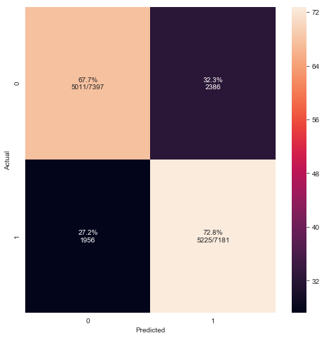

```python
print ("Confusion matrix for Naive Bayes Bernoulli Model - Unemployment:")
cm_analysis(y_testU, nb_un_preds_bernoulli, range(len(set(y_testU))), ymap=None, figsize=(8,8))
```

```
Confusion matrix for Naive Bayes Multinomial Model - Unemployment:
```

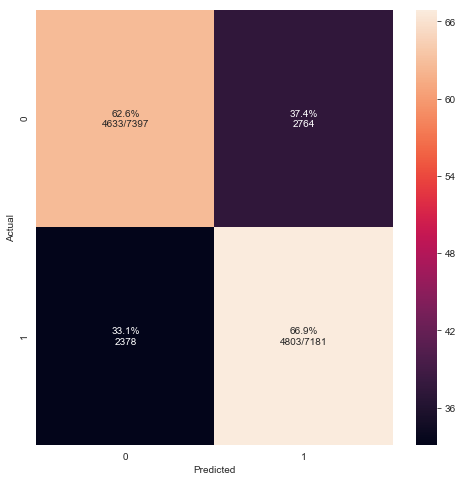

```python
print ("Confusion matrix for Naive Bayes Multinomial Model - Unemployment:")
cm_analysis(y_testU, nb_un_preds_multinomial, range(len(set(y_testU))), ymap=None, figsize=(8,8))
```

```
Confusion matrix for Naive Bayes Bernoulli Model - Child Poverty:
```

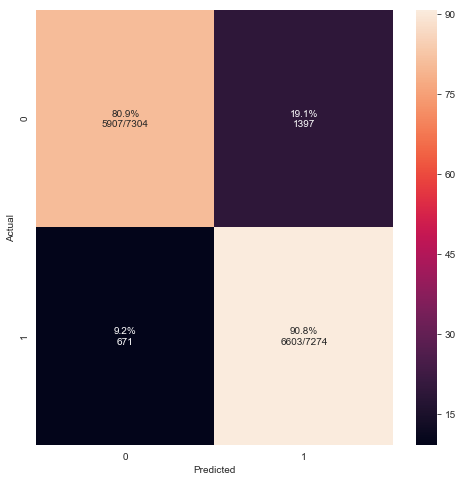

```python
print ("Confusion matrix for Naive Bayes Bernoulli Model - Child Poverty:")
cm_analysis(y_testCP, nb_cp_preds_bernoulli, range(len(set(y_testCP))), ymap=None, figsize=(8,8))
```

```
Confusion matrix for Naive Bayes Multinomial Model - Child Poverty:
```

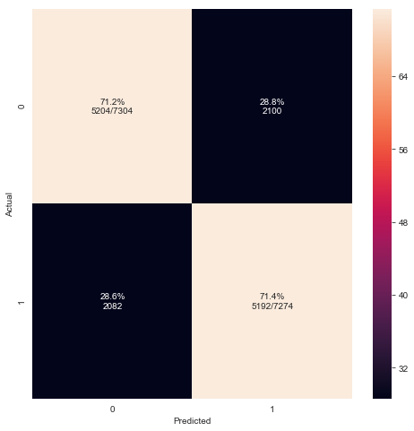

```python
print ("Confusion matrix for Naive Bayes Multinomial Model - Child Poverty:")
cm_analysis(y_testCP, nb_cp_preds_multinomial, range(len(set(y_testCP))), ymap=None, figsize=(8,8))
```

```
Confusion matrix for Random Forest Model - Unemployment:
```

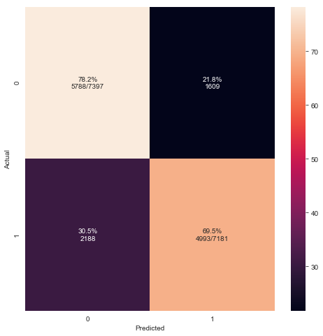

```python
print ("Confusion matrix for Random Forest Model - Unemployment:")
cm_analysis(y_testU, rf_preds_un, range(len(set(y_testU))), ymap=None, figsize=(8,8))
```

```
Confusion matrix for Random Forest Model - Child Poverty:
```

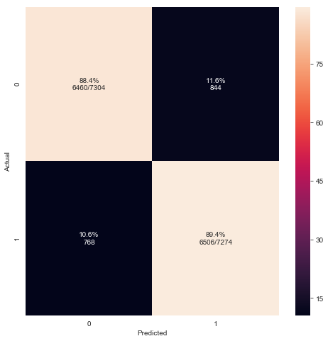

```python
print ("Confusion matrix for Random Forest Model - Child Poverty:")
cm_analysis(y_testCP, rf_preds_cp, range(len(set(y_testCP))), ymap=None, figsize=(8,8))
```

In the confusion matrices above, a perfect model would have white squares in the top left and bottom right corners, and black squares in the top right and bottom left corners, indicating perfect predictions. Clearly none of our models achieved this, but the more light/dark the colors are in those positions, the better. For instance, we can see that the Random Forest model directly above has very good predictive power for predicting child poverty. However, the Random Forest model predicting unemployment is not as good, indicated by the colors of the bottom two squares. The positions of the color variations help identify tradeoffs between the models. That Random Forest model, for example, has more trouble classifying neighborhoods that actually have high unemployment rates, whereas other models have more difficulty classifying neighborhood that actually have low unemployment rates. If they have similar accuracies, favoring one of these models over the other would depend on the goals of the organizations using them. Visualizing the confusion matrices with color scales helps to identify tradeoffs between models more easily than simply seeing accuracy/precision/recall scores.

### AUC and ROC curves

We are evaluating model performance comparison to pick up a better model that predicts the outcomes consistently. Here we use the classification score. However the Receiver Operating Characteristics (ROC) takes away the imbalances that exist between the classifiers and offers a better alternative to give models an edge. By looking at the Area Under the Curve (AUC) we can determine the outcome. Any AUC value less than half is a negative sign and anything above 0.5 is positive.

#### AUC and ROC curves for Unemployment

```
AUC and ROC Curves comparison of models - Unemployment
```

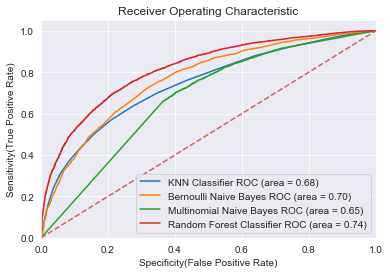

```python
print ("AUC and ROC Curves comparison of models - Unemployment")
from sklearn import metrics
import matplotlib.pyplot as plt

plt.figure()

# Add the models to the list that you want to view on the ROC plot
models = [
{
    'label': 'KNN Classifier',
    'model': KNeighborsClassifier(n_neighbors=bestK_u, weights='uniform', metric='euclidean'),
},
{
    'label': 'Bernoulli Naive Bayes',
    'model': BernoulliNB(alpha=0.001, binarize=10),
},
{
    'label': 'Multinomial Naive Bayes',
    'model': MultinomialNB(alpha=0.001),
},
{
    'label': 'Random Forest Classifier',
    'model': RandomForestClassifier(max_depth=5, n_estimators=10),
},
]

# Below for loop iterates through your models list
for m in models:
    model = m['model'] # select the model
    model.fit(X_trainU, y_trainU) # train the model
    y_pred=model.predict(X_testU) # predict the test data
# Compute False postive rate, and True positive rate
    fpr, tpr, thresholds = metrics.roc_curve(y_testU, model.predict_proba(X_testU)[:,1])
# Calculate Area under the curve to display on the plot
    auc = metrics.roc_auc_score(y_testU,model.predict(X_testU))
# Now, plot the computed values
    plt.plot(fpr, tpr, label='%s ROC (area = %0.2f)' % (m['label'], auc))
# Custom settings for the plot
plt.plot([0, 1], [0, 1],'r--')
plt.xlim([0.0, 1.0])
plt.ylim([0.0, 1.05])
plt.xlabel('Specificity(False Positive Rate)')
plt.ylabel('Sensitivity(True Positive Rate)')
plt.title('Receiver Operating Characteristic')
plt.legend(loc="lower right")
plt.show()   # Actual plot
```

In an ROC curve, we would like to see a curve that most closely resembles a line going straight up and then straight across, i.e. it should get close to the (0,1) point and have an AUC as close as possible to 1. Based on the AUC and ROC curves we see that the best model for predicting Unemployment is our Random Forest model, followed by the Bernoulli Naive Bayes, followed by KNN and then Multinomial Naive Bayes models.

#### AUC and ROC curves for Child Poverty

```
AUC and ROC Curves comparison of models - Child Poverty
```

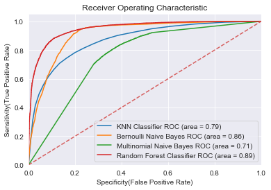

```python
print ("AUC and ROC Curves comparison of models - Child Poverty")
from sklearn import metrics
import matplotlib.pyplot as plt

plt.figure()

# Add the models to the list that you want to view on the ROC plot
models = [
{
    'label': 'KNN Classifier',
    'model': KNeighborsClassifier(n_neighbors=bestK_cp, weights='uniform', metric='euclidean'),
},
{
    'label': 'Bernoulli Naive Bayes',
    'model': BernoulliNB(alpha=0.001, binarize=10),
},
{
    'label': 'Multinomial Naive Bayes',
    'model': MultinomialNB(alpha=0.001),
},
{
    'label': 'Random Forest Classifier',
    'model': RandomForestClassifier(max_depth=5, n_estimators=10),
},
]

# Below for loop iterates through your models list
for m in models:
    model = m['model'] # select the model
    model.fit(X_trainCP, y_trainCP) # train the model
    y_pred=model.predict(X_testCP) # predict the test data
# Compute False postive rate, and True positive rate
    fpr, tpr, thresholds = metrics.roc_curve(y_testCP, model.predict_proba(X_testCP)[:,1])
# Calculate Area under the curve to display on the plot
    auc = metrics.roc_auc_score(y_testCP,model.predict(X_testCP))
# Now, plot the computed values
    plt.plot(fpr, tpr, label='%s ROC (area = %0.2f)' % (m['label'], auc))
# Custom settings for the plot
plt.plot([0, 1], [0, 1],'r--')
plt.xlim([0.0, 1.0])
plt.ylim([0.0, 1.05])
plt.xlabel('Specificity(False Positive Rate)')
plt.ylabel('Sensitivity(True Positive Rate)')
plt.title('Receiver Operating Characteristic')
plt.legend(loc="lower right")
plt.show()   # Actual plot
```

From the AUC and ROC curves, the best model for predicting Child Poverty is the Random Forest model, followed by the Bernoulli Naive Bayes, followed by the KNN and Multinomial Naive Bayes models. This is the same ranking we found from models predicting Unemployment, which may indicate certain characteristics of our dataset. These ROC curves look better overall than the models predicting unemployment, indicating there are better predictors available for child poverty.

#### Predicting Unemployment - Model Comparison

[output not shown]

Overall, the metrics indicate that Random Forest is the best model in predicting Unemployment, achieving an accuracy of 74%. The Bernoulli Naive Bayes model is the next best, and actually has better recall than RF which may be more valuable for some use cases.

#### Predicting Child Poverty - Model Comparison

[output not shown]

Metrics indicate that the Random Forest model is the best model in predicting Child Poverty, achieving a very good accuracy of 89%. The Bernoulli Naive Bayes model is fairly close behind with an accuracy of 86%, but is actually has better recall than RF which may be more valuable for some use cases.

# Modeling and Evaluation 5

**Rubric 7:** Discuss the advantages of each model for each classification task, if any. If there are not advantages, explain why. Is any model better than another? Is the difference significant with 95% confidence? Use proper statistical comparison methods. You must use statistical comparison techniques—be sure they are appropriate for your chosen method of validation as discussed in unit 7 of the course.

Accuracy ignores the cost of misclassifications. The effect of small size does not arise here as we have lots of objects for training. As these are complex models, we could expect lower bias but high variance. For this we need to ensure we are not overfitting the data. For this reason we did the Stratified shuffle split on the data set for training and test sets of objects. A higher F-measure would always be better as we need to have lower false positives and false negatives for comparison to arrive at the best model. We would also try to compare the cost based weighted accuracy over accuracy calculated on the confusion matrix. Here lower cost is always better.

The metric we used to evaluate the difference between models is the logarithmic loss, or logloss.

**Logarithmic Loss:**

- Evaluating the predictions of probabilities of membership to a given class.
- The scalar probability between 0 and 1 can be seen as a measure of confidence for a prediction by an algorithm.
- Predictions that are correct or incorrect are rewarded or punished proportionally to the confidence of the prediction.
- Smaller logloss is better with 0 representing a perfect logloss.

#### Classification confidence intervals for Unemployment

```python
from sklearn.model_selection import cross_val_score
from sklearn.metrics import f1_score
from statsmodels.stats.weightstats import _zconfint_generic, _tconfint_generic


models = [
{
    'label': 'KNN Classifier',
    'model': KNeighborsClassifier(n_neighbors=bestK_cp, weights='uniform', metric='euclidean'),
},
{
    'label': 'Bernoulli Naive Bayes',
    'model': BernoulliNB(alpha=0.001, binarize=10),
},
{
    'label': 'Multinomial Naive Bayes',
    'model': MultinomialNB(alpha=0.001),
},
{
    'label': 'Random Forest Classifier',
    'model': RandomForestClassifier(max_depth=5, n_estimators=10),
},
]

# Below for loop iterates through your models list
for m in models:
    model = m['model'] # select the model
    model.fit(X_trainU, y_trainU) # train the model
    y_pred=model.predict(X_testU) # predict the test data
    f1score = cross_val_score(model, X_trainU, y_trainU, scoring='f1', cv=10)
    logloss_score = cross_val_score(model, X_trainU, y_trainU, scoring='neg_log_loss', cv=10)
    mean = f1score.mean()
    print(m['label'])
    print("Model F1-score: mean %.3f, std %.3f" % (f1score.mean(), f1score.std(ddof=1)))
    mean_std = f1score.std(ddof=1)/np.sqrt(len(f1score))
    tconf = _tconfint_generic(mean, mean_std, len(f1score) - 1, 0.05, 'two-sided')
    print("Model F1-score 95% confidence interval:", tconf)
    print("Logloss: %.3f (%.3f)" % (logloss_score.mean(), logloss_score.std()))
    print('----------------------------------------')
```

```
KNN Classifier
Model F1-score: mean 0.656, std 0.007
Model F1-score 95% confidence interval: (0.6511900069104533, 0.6610271110692632)
Logloss: -0.684 (0.016)
----------------------------------------
Bernoulli Naive Bayes
Model F1-score: mean 0.704, std 0.007
Model F1-score 95% confidence interval: (0.6990177473679539, 0.7083234034077047)
Logloss: -0.640 (0.011)
----------------------------------------
Multinomial Naive Bayes
Model F1-score: mean 0.650, std 0.006
Model F1-score 95% confidence interval: (0.6455758040730344, 0.6538521781402673)
Logloss: -11.950 (0.199)
----------------------------------------
Random Forest Classifier
Model F1-score: mean 0.724, std 0.007
Model F1-score 95% confidence interval: (0.7187021535132283, 0.7288876202505372)
Logloss: -0.533 (0.004)
----------------------------------------
```

### Conclusion of best model for Unemployment prediction

So overall, the RF model has the biggest advantage over all the other models in terms of metrics. As we saw before, the Bernoulli NB model outscored RF in recall, which might be more useful in some use cases, but overall RF is preferred. The other models (KNN and Multinomial NB) do not really have advantages, as they underperform in all of the metrics. RF was the slowest model to train, but not much slower to make a practical difference, even with our rather large dataset (37 ms vs 1-10 ms).

#### Classification confidence intervals for Child Poverty

```python
from sklearn.model_selection import cross_val_score
from sklearn.metrics import f1_score
from statsmodels.stats.weightstats import _zconfint_generic, _tconfint_generic


models = [
{
    'label': 'KNN Classifier',
    'model': KNeighborsClassifier(n_neighbors=bestK_cp, weights='uniform', metric='euclidean'),
},
{
    'label': 'Bernoulli Naive Bayes',
    'model': BernoulliNB(alpha=0.001, binarize=10),
},
{
    'label': 'Multinomial Naive Bayes',
    'model': MultinomialNB(alpha=0.001),
},
{
    'label': 'Random Forest Classifier',
    'model': RandomForestClassifier(max_depth=5, n_estimators=10),
},
]

# Below for loop iterates through your models list
for m in models:
    model = m['model'] # select the model
    model.fit(X_trainCP, y_trainCP) # train the model
    y_pred=model.predict(X_testCP) # predict the test data
    f1score = cross_val_score(model, X_trainCP, y_trainCP, scoring='f1', cv=10)
    logloss_score = cross_val_score(model, X_trainCP, y_trainCP, scoring='neg_log_loss', cv=10)
    mean = f1score.mean()
    print(m['label'])
    print("Model F1-score: mean %.3f, std %.3f" % (f1score.mean(), f1score.std(ddof=1)))
    mean_std = f1score.std(ddof=1)/np.sqrt(len(f1score))
    tconf = _tconfint_generic(mean, mean_std, len(f1score) - 1, 0.05, 'two-sided')
    print("Model F1-score 95% confidence interval:", tconf)
    print("Logloss: %.3f (%.3f)" % (logloss_score.mean(), logloss_score.std()))
    print('----------------------------------------')
```

```
KNN Classifier
Model F1-score: mean 0.789, std 0.007
Model F1-score 95% confidence interval: (0.7841421898416522, 0.7940591081511715)
Logloss: -0.674 (0.023)
----------------------------------------
Bernoulli Naive Bayes
Model F1-score: mean 0.866, std 0.004
Model F1-score 95% confidence interval: (0.8625382003467845, 0.8685810500922997)
Logloss: -0.386 (0.009)
----------------------------------------
Multinomial Naive Bayes
Model F1-score: mean 0.715, std 0.004
Model F1-score 95% confidence interval: (0.712632009595657, 0.7182247157507536)
Logloss: -9.650 (0.126)
----------------------------------------
Random Forest Classifier
Model F1-score: mean 0.883, std 0.006
Model F1-score 95% confidence interval: (0.8781820497133475, 0.8869924999311625)
Logloss: -0.309 (0.016)
----------------------------------------
```

### Conclusion of best model for Child Poverty prediction

So overall, the RF model has the biggest advantage over all the other models in terms of metrics. As we saw before, the Bernoulli NB model outscored RF in recall, which might be more useful in some use cases, but RF would generally be preferred. The other models (KNN and Multinomial NB) do not really have advantages, as they underperform in all of the metrics. RF was the slowest model to train, but not much slower to make a practical difference, even with our rather large dataset (37 ms vs 1-10 ms).

# Modeling and Evaluation 6

**Rubric 8:** Which attributes from your analysis are most important? Use proper methods discussed in class to evaluate the importance of different attributes. Discuss the results and hypothesize about why certain attributes are more important than others for a given classification task.

### Important Variables - Unemployment

[figure not shown]

```python
plt.barh(df_17_model.columns, rfclf_u.feature_importances_);
plt.title("Feature importance - Unemployment")
plt.show()
```

While the percentage of employed people is not a direct inverse to the unemployed population, they are certainly correlated and thus it makes sense that the Employed variable plays a large role in predicting Unemployment. In addition, the relationships between Poverty and Income to Unemployment are intuitive as well. However, it is interesting to see that the Professional variables plays a role in predicting Unemployment, since this indicates that the presence of business/management type jobs influences the overall job market in a particular area. We have explored previously that racial distributions play a significant role in ecomonic status in neighborhoods, which is again reflected in this model.

### Important Variables - Child Poverty

For predicting Child Poverty from the bar chart below shows that overall Poverty (which is correlated and hence not a major find), Income, Employed, Professional, Service, Black, Voting Age Citizen and White are some of the top features in our Random Forest Classifier, which was our highest performing model. These would be main contributors to the dependent classifier variable, namely High Child poverty in our models.

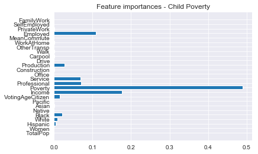

```python
plt.barh(df_17_model.columns, rfclf_cp.feature_importances_);
plt.title("Feature importance - Child Poverty")
plt.show()
```

The variables of Poverty and Child Poverty were correlated, and thus it makes sense that Poverty plays a major role in predicting Child Poverty. Income levels are also an intuitive indicator of Child Poverty, as reflected in the model. It is more interesting that the Professional and Service variables are important predictors. These indicate that when more people in a neighborhood have business vs service jobs, the children of these people are influenced heavily. Again, we have explored the impact of racial distributions on neighborhoods, which is reflected in this model as well.

# Deployment

**Rubric 9:** How useful is your model for interested parties (i.e., the companies or organizations that might want to use it for prediction)? How would you measure the model's value if it was used by these parties? How would your deploy your model for interested parties? What other data should be collected? How often would the model need to be updated, etc.?

We believe our models could be fairly useful for interested parties, who would likely be philanthropic organizations seeking to bring economic development or aid to areas in need. Our models, specifically the Random Forest models for predicting unemployment and child poverty, achieved decent accuracy levels. We would count it a success if the use of our models led those organizations to aid significantly more neighborhoods than they were before using our models, because they were able to more successfully identify areas in need through our models.

The process of deploying our model would be somewhat dependent on the organization we were deploying it for. This is because they may want to use our models to predict unemployment or child poverty on their own data, but they may not have as many predictor variables as we used to train our models. Thus we would trim down our training sets and models based on the data we knew would be coming in. Beyond this, however, deploying our models might involve setting up a server and then setting up endpoints so that the company could make API requests to predict data points individually or in batches.

Another option might be to use an existing service such as Deep Cognition (reference below) to host our models. This would require additional research and possibly more expenses, but would likely require less technical knowledge of setting up a server, endpoints, etc. which might be a limiting factor.

The source of our data from was only a subset of the available attributes recorded by the U.S. government. We could retrieve additional features to make the deployed models even more generalized to the data that interested parties might have. In addition, the models should be updated every few years (say, every 5-10 years) to remain current. This works well with the U.S. census data that we trained our models on, since they are taken every 10 years but yearly estimates are published as well.

# Exceptional Work

**Rubric 10:** You have free reign to provide additional analyses. One idea: grid search parameters in a parallelized fashion and visualize the performances across attributes. Which parameters are most significant for making a good model for each classification algorithm?

### Grid Search best parameters

Here we do grid search to optimize the parameters of the models chosen for Unemployment and Child poverty predicions. The Grid search explores the same set of parameters while the run times to execute are lower. The result gives us Grid search best estimator parameters and best score and grid search Best parameters. This can be used for adjusting our model for predictions.

#### Grid Search best Bernoulli Naive Bayes model

For unemployment prediction

```python
# Bernoulli NB with Grid Search for Unemployment:
from sklearn.model_selection import GridSearchCV
alphas = {'alpha': [0.001, 0.01, 0.1, 0.5, 1.0, 2.0, 10.0]}
clf_bnb_u = GridSearchCV(BernoulliNB(),alphas, n_jobs=-1, cv=5)
print('Grid Search Best Estimator Parameters:', clf_bnb_u.fit(X_trainU, y_trainU))
print('----------------------------------------')
print('Grid Search Best Score:', clf_bnb_u.best_score_)
print('----------------------------------------')
print('Grid Search Best Parameters:', clf_bnb_u.best_params_)
print('----------------------------------------')
clf_bnb_u_predictions = clf_bnb_u.best_estimator_.predict(X_testU)
clf_bnb_u_accuracy = round(accuracy_score(y_testU,clf_bnb_u_predictions), 3)
clf_bnb_u_precision = round(precision_score(y_testU,clf_bnb_u_predictions), 3)
clf_bnb_u_recall = round(recall_score(y_testU,clf_bnb_u_predictions), 3)
# Print the metrics
print ("Accuracy for Bernoulli NB Model: ", clf_bnb_u_accuracy)
print('Precision for Bernoulli NB Model:', clf_bnb_u_precision)
print('Recall for Bernoulli NB Model:', clf_bnb_u_recall)
```

```
Grid Search Best Estimator Parameters: GridSearchCV(cv=5, error_score='raise-deprecating',
       estimator=BernoulliNB(alpha=1.0, binarize=0.0, class_prior=None, fit_prior=True),
       fit_params=None, iid='warn', n_jobs=-1,
       param_grid={'alpha': [0.001, 0.01, 0.1, 0.5, 1.0, 2.0, 10.0]},
       pre_dispatch='2*n_jobs', refit=True, return_train_score='warn',
       scoring=None, verbose=0)
----------------------------------------
Grid Search Best Score: 0.5738711392361647
----------------------------------------
Grid Search Best Parameters: {'alpha': 0.5}
----------------------------------------
Accuracy for Bernoulli NB Model:  0.571
Precision for Bernoulli NB Model: 0.6
Recall for Bernoulli NB Model: 0.39
```

#### Grid Search best Bernoulli Naive Bayes model

For Child Poverty Prediction

```python
# Bernoulli NB with Grid Search for Child Poverty:
from sklearn.model_selection import GridSearchCV
alphas = {'alpha': [0.001, 0.01, 0.1, 0.5, 1.0, 2.0, 10.0]}
clf_bnb_cp = GridSearchCV(BernoulliNB(),alphas, n_jobs=-1, cv=5)
print('Grid Search Best Estimator Parameters:', clf_bnb_cp.fit(X_trainCP, y_trainCP))
print('----------------------------------------')
print('Grid Search Best Score:', clf_bnb_cp.best_score_)
print('----------------------------------------')
print('Grid Search Best Parameters:', clf_bnb_cp.best_params_)
print('----------------------------------------')
clf_bnb_cp_predictions = clf_bnb_cp.best_estimator_.predict(X_testCP)
clf_bnb_cp_accuracy = round(accuracy_score(y_testCP,clf_bnb_cp_predictions), 3)
clf_bnb_cp_precision = round(precision_score(y_testCP,clf_bnb_cp_predictions), 3)
clf_bnb_cp_recall = round(recall_score(y_testCP,clf_bnb_cp_predictions), 3)
# Print the metrics
print ("Accuracy for Bernoulli NB Model: ", clf_bnb_cp_accuracy)
print('Precision for Bernoulli NB Model:', clf_bnb_cp_precision)
print('Recall for Bernoulli NB Model:', clf_bnb_cp_recall)
```

```
Grid Search Best Estimator Parameters: GridSearchCV(cv=5, error_score='raise-deprecating',
       estimator=BernoulliNB(alpha=1.0, binarize=0.0, class_prior=None, fit_prior=True),
       fit_params=None, iid='warn', n_jobs=-1,
       param_grid={'alpha': [0.001, 0.01, 0.1, 0.5, 1.0, 2.0, 10.0]},
       pre_dispatch='2*n_jobs', refit=True, return_train_score='warn',
       scoring=None, verbose=0)
----------------------------------------
Grid Search Best Score: 0.6023734801323936
----------------------------------------
Grid Search Best Parameters: {'alpha': 1.0}
----------------------------------------
Accuracy for Bernoulli NB Model:  0.597
Precision for Bernoulli NB Model: 0.678
Recall for Bernoulli NB Model: 0.368
```

#### Grid Search best Multinomial Naive Bayes model

For unemployment Prediction

```python
# Multinomial NB with Grid Search for Unemployment:
from sklearn.model_selection import GridSearchCV
alphas = {'alpha': [0.001, 0.01, 0.1, 0.5, 1.0, 2.0, 10.0]}
clf_mnb_u = GridSearchCV(MultinomialNB(),alphas, n_jobs=-1, cv=5)
print('Grid Search Best Estimator Parameters:', clf_mnb_u.fit(X_trainU, y_trainU))
print('----------------------------------------')
print('Grid Search Best Score:', clf_mnb_u.best_score_)
print('----------------------------------------')
print('Grid Search Best Parameters:', clf_mnb_u.best_params_)
print('----------------------------------------')
clf_mnb_u_predictions = clf_mnb_u.best_estimator_.predict(X_testU)
clf_mnb_u_accuracy = round(accuracy_score(y_testU,clf_mnb_u_predictions), 3)
clf_mnb_u_precision = round(precision_score(y_testU,clf_mnb_u_predictions), 3)
clf_mnb_u_recall = round(recall_score(y_testU,clf_mnb_u_predictions), 3)
# Print the metrics
print ("Accuracy for Multinomial NB Model: ", clf_mnb_u_accuracy)
print('Precision for Multinomial NB Model:', clf_mnb_u_precision)
print('Recall for Multinomial NB Model:', clf_mnb_u_recall)
```

```
Grid Search Best Estimator Parameters: GridSearchCV(cv=5, error_score='raise-deprecating',
       estimator=MultinomialNB(alpha=1.0, class_prior=None, fit_prior=True),
       fit_params=None, iid='warn', n_jobs=-1,
       param_grid={'alpha': [0.001, 0.01, 0.1, 0.5, 1.0, 2.0, 10.0]},
       pre_dispatch='2*n_jobs', refit=True, return_train_score='warn',
       scoring=None, verbose=0)
----------------------------------------
Grid Search Best Score: 0.6456414741643943
----------------------------------------
Grid Search Best Parameters: {'alpha': 0.001}
----------------------------------------
Accuracy for Multinomial NB Model:  0.647
Precision for Multinomial NB Model: 0.634
Recall for Multinomial NB Model: 0.67
```

#### Grid Search best Multinomial Naive Bayes model

For Child Poverty Prediction

```python
# Multinomial NB with Grid Search for Child Poverty:
from sklearn.model_selection import GridSearchCV
alphas = {'alpha': [0.001, 0.01, 0.1, 0.5, 1.0, 2.0, 10.0]}
clf_mnb_cp = GridSearchCV(MultinomialNB(),alphas, n_jobs=-1, cv=5)
print('Grid Search Best Estimator Parameters:', clf_mnb_cp.fit(X_trainCP, y_trainCP))
print('----------------------------------------')
print('Grid Search Best Score:', clf_mnb_cp.best_score_)
print('----------------------------------------')
print('Grid Search Best Parameters:', clf_mnb_cp.best_params_)
print('----------------------------------------')
clf_mnb_cp_predictions = clf_mnb_cp.best_estimator_.predict(X_testCP)
clf_mnb_cp_accuracy = round(accuracy_score(y_testCP,clf_mnb_cp_predictions), 3)
clf_mnb_cp_precision = round(precision_score(y_testCP,clf_mnb_cp_predictions), 3)
clf_mnb_cp_recall = round(recall_score(y_testCP,clf_mnb_cp_predictions), 3)
# Print the metrics
print ("Accuracy for Multinomial NB Model: ", clf_mnb_cp_accuracy)
print('Precision for Multinomial NB Model:', clf_mnb_cp_precision)
print('Recall for Multinomial NB Model:', clf_mnb_cp_recall)
```

```
Grid Search Best Estimator Parameters: GridSearchCV(cv=5, error_score='raise-deprecating',
       estimator=MultinomialNB(alpha=1.0, class_prior=None, fit_prior=True),
       fit_params=None, iid='warn', n_jobs=-1,
       param_grid={'alpha': [0.001, 0.01, 0.1, 0.5, 1.0, 2.0, 10.0]},
       pre_dispatch='2*n_jobs', refit=True, return_train_score='warn',
       scoring=None, verbose=0)
----------------------------------------
Grid Search Best Score: 0.7162799471797774
----------------------------------------
Grid Search Best Parameters: {'alpha': 0.001}
----------------------------------------
Accuracy for Multinomial NB Model:  0.707
Precision for Multinomial NB Model: 0.707
Recall for Multinomial NB Model: 0.704
```

#### Grid Search best Random Forest model

For unemployment Prediction

```python
# Random Forest with Grid Search for Unemployment
from sklearn.model_selection import GridSearchCV
from sklearn.model_selection import KFold
grid_1 = { "n_estimators"      : [100,200,500],
               "criterion"         : ["gini","entropy"],
               "max_features"      : ['auto'],
               "max_depth"         : [3,4,6,10],
               "min_samples_split"  : [3]
         }
RF=RandomForestClassifier()
rfclf_u = GridSearchCV(RF, grid_1, n_jobs=-1, cv=5)
print('Grid Search Best Estimator Parameters:', rfclf_u.fit(X_trainU, y_trainU))
print('----------------------------------------')
print('Grid Search Best Score:', rfclf_u.best_score_)
print('----------------------------------------')
print('Grid Search Best Parameters:', rfclf_u.best_params_)
print('----------------------------------------')
rfclf_u_predictions = rfclf_u.best_estimator_.predict(X_testU)
rfclf_u_accuracy = round(accuracy_score(y_testU,rfclf_u_predictions), 3)
rfclf_u_precision = round(precision_score(y_testU,rfclf_u_predictions), 3)
rfclf_u_recall = round(recall_score(y_testU,rfclf_u_predictions), 3)
# Print the metrics
print ("Accuracy for Random Forest Model: ", rfclf_u_accuracy)
print('Precision for Random Forest Model:', rfclf_u_precision)
print('Recall for Random Forest Model:', rfclf_u_recall)
```

```
Grid Search Best Estimator Parameters: GridSearchCV(cv=5, error_score='raise-deprecating',
       estimator=RandomForestClassifier(bootstrap=True, class_weight=None, criterion='gini',
            max_depth=None, max_features='auto', max_leaf_nodes=None,
            min_impurity_decrease=0.0, min_impurity_split=None,
            min_samples_leaf=1, min_samples_split=2,
            min_weight_fraction_leaf=0.0, n_estimators='warn', n_jobs=None,
            oob_score=False, random_state=None, verbose=0,
            warm_start=False),
       fit_params=None, iid='warn', n_jobs=-1,
       param_grid={'n_estimators': [100, 200, 500], 'criterion': ['gini', 'entropy'], 'max_features': ['auto'], 'max_depth': [3, 4, 6, 10], 'min_samples_split': [3]},
       pre_dispatch='2*n_jobs', refit=True, return_train_score='warn',
       scoring=None, verbose=0)
----------------------------------------
Grid Search Best Score: 0.7482293220833119
----------------------------------------
Grid Search Best Parameters: {'criterion': 'gini', 'max_depth': 10, 'max_features': 'auto', 'min_samples_split': 3, 'n_estimators': 200}
----------------------------------------
Accuracy for Random Forest Model:  0.749
Precision for Random Forest Model: 0.759
Recall for Random Forest Model: 0.72
```

#### Grid Search best Random Forest model

For Child Poverty Prediction

```python
# Random Forest with Grid Search for Child Poverty
from sklearn.model_selection import GridSearchCV
from sklearn.model_selection import KFold
grid_1 = { "n_estimators"      : [100,200,500],
               "criterion"         : ["gini","entropy"],
               "max_features"      : ['auto'],
               "max_depth"         : [3,4,6,10],
               "min_samples_split"  : [3]
         }
RF=RandomForestClassifier()
rfclf_cp = GridSearchCV(RF, grid_1, n_jobs=-1, cv=5)
print('Grid Search Best Estimator Parameters:', rfclf_cp.fit(X_trainCP, y_trainCP))
print('----------------------------------------')
print('Grid Search Best Score:', rfclf_cp.best_score_)
print('----------------------------------------')
print('Grid Search Best Parameters:', rfclf_cp.best_params_)
print('----------------------------------------')
rfclf_cp_predictions = rfclf_cp.best_estimator_.predict(X_testCP)
rfclf_cp_accuracy = round(accuracy_score(y_testU,rfclf_cp_predictions), 3)
rfclf_cp_precision = round(precision_score(y_testU,rfclf_cp_predictions), 3)
rfclf_cp_recall = round(recall_score(y_testU,rfclf_cp_predictions), 3)
# Print the metrics
print ("Accuracy for Random Forest Model: ", rfclf_cp_accuracy)
print('Precision for Random Forest Model:', rfclf_cp_precision)
print('Recall for Random Forest Model:', rfclf_cp_recall)
```

```
Grid Search Best Estimator Parameters: GridSearchCV(cv=5, error_score='raise-deprecating',
       estimator=RandomForestClassifier(bootstrap=True, class_weight=None, criterion='gini',
            max_depth=None, max_features='auto', max_leaf_nodes=None,
            min_impurity_decrease=0.0, min_impurity_split=None,
            min_samples_leaf=1, min_samples_split=2,
            min_weight_fraction_leaf=0.0, n_estimators='warn', n_jobs=None,
            oob_score=False, random_state=None, verbose=0,
            warm_start=False),
       fit_params=None, iid='warn', n_jobs=-1,
       param_grid={'n_estimators': [100, 200, 500], 'criterion': ['gini', 'entropy'], 'max_features': ['auto'], 'max_depth': [3, 4, 6, 10], 'min_samples_split': [3]},
       pre_dispatch='2*n_jobs', refit=True, return_train_score='warn',
       scoring=None, verbose=0)
----------------------------------------
Grid Search Best Score: 0.8920786815523658
----------------------------------------
Grid Search Best Parameters: {'criterion': 'gini', 'max_depth': 10, 'max_features': 'auto', 'min_samples_split': 3, 'n_estimators': 500}
----------------------------------------
Accuracy for Random Forest Model:  0.502
Precision for Random Forest Model: 0.495
Recall for Random Forest Model: 0.514
```

#### References

1. https://www.programcreek.com/python/example/91149/sklearn.model_selection.StratifiedShuffleSplit
2. https://towardsdatascience.com/receiver-operating-characteristic-curves-demystified-in-python-bd531a4364d0
3. https://stackoverflow.com/questions/42894871/how-to-plot-multiple-roc-curves-in-one-plot-with-legend-and-auc-scores-in-python
4. https://scikit-learn.org/stable/auto_examples/model_selection/plot_randomized_search.html
5. https://towardsdatascience.com/deploying-deep-learning-models-e9e4d7dda3ff